# LxM Supplementary Figures

Calum Guinea

2026-07-14

# Overview

This notebook generates all publication-ready figures from the LxM (Learning × Motivation) manuscript. Each figure is clearly labeled and organized by manuscript section (main figures and supplementary figures).

**To use this notebook:** keep this file, `data/`, and `LxM_load_and_preprocess.R` together, then click “Knit”. No paths to edit.

[output not shown]

# Setup

## Locate the Data Folder

```r
# Folder holding the raw CSVs, next to this .Rmd file
data_dir <- file.path("data")
required_files <- c("allMeanTbtEst.csv", "allEstsByStim.csv",
                     "choice_trialByTrial.csv", "summaryFull.csv")

# Fail early with a clear message if a file is missing, rather than a
# cryptic error later in the notebook
missing_files <- required_files[!file.exists(file.path(data_dir, required_files))]
if (length(missing_files) > 0) {
  stop("Missing data file(s): ", paste(missing_files, collapse = ", "),
       "\nExpected them in: ", normalizePath(data_dir, mustWork = FALSE))
}
if (!file.exists("LxM_load_and_preprocess.R")) {
  stop("Missing LxM_load_and_preprocess.R - it should sit next to this .Rmd file")
}
```

## Install Packages (if needed)

Run this chunk once if you need to install packages:

```r
install.packages(c("dplyr", "tidyr", "ggplot2", "ggdist",
                   "ggbeeswarm", "cowplot", "ggpubr", "RColorBrewer",
                   "reshape2", "colorspace", "ggsci", "corrplot"))
```

## Load Required Packages

```r
library(dplyr)       # Data manipulation
library(tidyr)       # Data tidying
library(ggplot2)     # Plotting
library(ggdist)      # Distribution visualizations
library(ggbeeswarm)  # Beeswarm plots
library(cowplot)     # Publication-ready themes
library(ggpubr)      # Publication-ready plots
library(RColorBrewer)# Color palettes
library(reshape2)    # Data reshaping
library(colorspace)  # Color utilities
library(ggsci)       # Scientific journal color palettes
library(corrplot)    # Correlation matrix plots
```

# Data Loading and Preprocessing

## Load Preprocessing Script

```r
# Source the preprocessing script
# This script contains the lxm_load_preprocess() function
source('LxM_load_and_preprocess.R')
```

## Load and Preprocess Data

```r
# Load and preprocess the data
# clean = 1: Apply data cleaning
# tourn_remove = 1: Remove participants with poor tournament performance
data <- lxm_load_preprocess(clean = 1, tourn_remove = 1)

# Extract trial-by-trial and summary dataframes
tbtDf <- data$tbtDf    # Trial-by-trial data
summDf <- data$summDf  # Summary statistics per participant
```

# Main Manuscript Figures

## Figure 2 - Learning Trajectories

Shows how participants learned stimulus outcome probabilities across trials during the learning phase.

```r
# Read raw estimation data files
# allMeanTbtEst.csv contains mean estimates across participants
# allEstsByStim.csv contains individual participant estimates by stimulus
data_means <- read.csv(file.path(data_dir, "allMeanTbtEst.csv"), header = FALSE)
rawEstData <- read.csv(file.path(data_dir, "allEstsByStim.csv"), header = FALSE)

# Convert raw matrix to tibble for easier manipulation
df <- as_tibble(rawEstData)

# Rename columns for clarity
# First column is stimulus ID, remaining columns are trials (t1, t2, ...)
colnames(df) <- c("stimulus", paste0("t", 1:(ncol(df)-1)))

# Pivot to long format: one row per participant × trial
# This makes it easier to calculate statistics and plot
long_df <- df %>%
  pivot_longer(
    cols = starts_with("t"),          # Select all trial columns
    names_to = "trial",                # New column for trial number
    names_prefix = "t",                # Remove "t" prefix
    names_transform = list(trial = as.integer),  # Convert to integer
    values_to = "estimate"             # Values go into "estimate" column
  )

# Calculate mean and standard error per stimulus × trial
# These will be used for the line plot and confidence ribbons
summary_df <- long_df %>%
  group_by(stimulus, trial) %>%
  summarize(
    mean_est = mean(estimate, na.rm = TRUE),           # Average estimate
    se_est = sd(estimate, na.rm = TRUE) / sqrt(n()),   # Standard error
    .groups = "drop"
  )

# Create the learning trajectory plot
# Each stimulus gets its own panel showing learning over trials
p <- ggplot(summary_df, aes(x = trial, y = mean_est,
                            color = factor(stimulus),
                            group = factor(stimulus))) +
  # Add line connecting trial means
  geom_line(linewidth = 0.5) +
  # Add points for each trial
  geom_point(size = 1.2) +
  # Add shaded confidence ribbon (mean ± SE)
  geom_ribbon(aes(ymin = mean_est - se_est, ymax = mean_est + se_est,
                  fill = factor(stimulus)),
              alpha = 0.4, color = NA) +
  # Add horizontal dashed lines showing true outcome probabilities
  # Stimuli 1,3,5,7 have p=0.25; Stimuli 2,4,6,8 have p=0.75
  geom_hline(data = data.frame(
    stimulus = 1:8,
    h_line = ifelse(c(1:8) %in% c(1, 3, 5, 7), 0.25, 0.75)),
    aes(yintercept = h_line),
    linetype = "dashed", color = "black") +
  # Show trial numbers every 3 trials
  scale_x_continuous(breaks = seq(1, 16, by = 3)) +
  # Create separate panel for each stimulus
  facet_wrap(~ stimulus, ncol = 2,
             labeller = labeller(stimulus = function(x) paste("Stimulus", x))) +
  # Set y-axis limits (probabilities range from 0 to 1)
  ylim(0, 1) +
  labs(
    x = "Trial",
    y = "Average Rating",
    color = "Stimulus",
    fill = "Stimulus"
  ) +
  theme_minimal(base_size = 20) +
  theme(
    legend.position = "bottom",
    panel.background = element_rect(fill = "white", colour = "white"),
    panel.grid.minor = element_blank(),
    strip.background = element_rect(fill = "lightgray", color = NA),
    strip.text = element_text(face = "bold")
  )

print(p)
```

[figure not shown]

# Supplementary Figures

## Supplementary Figure 1 - Maximum Voluntary Contraction (MVC)

Shows each participant’s maximum key presses per second. The horizontal line at 19 indicates the minimum threshold used to exclude participants with insufficient effort capacity.

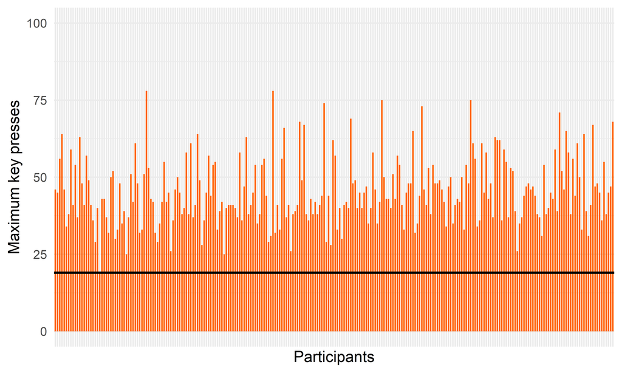

```r
# Create bar plot showing MVC for each participant
# MVC = Maximum Voluntary Contraction (max key presses per second)
mvcBar <- ggplot(summDf, aes(x = prolificID, y = mvc, fill = "#ff6201")) +
  # Create bar for each participant
  geom_bar(stat = "identity", position = position_dodge(width = 0.8), width = 0.7) +
  # Add horizontal line showing minimum threshold (19 presses)
  geom_hline(yintercept = 19, color = "black", linetype = "solid", linewidth = 1.25) +
  scale_fill_manual(values = "#ff6201") +
  labs(
    x = "Participants",
    y = "Maximum key presses") +
  theme_minimal(base_size = 18) +
  theme(
    legend.position = "none",
    axis.text.x = element_blank(),              # Hide participant IDs
    panel.background = element_rect(fill = "white", colour = "white"),
    axis.ticks.x = element_blank(),
    axis.text.x.bottom = element_blank()) +
  ylim(0, 100)  # Set y-axis limits

print(mvcBar)
```

## Supplementary Figure 2 - Mean Post-Task Estimates

Raincloud plots showing distribution of mean post-task probability estimates across three timepoints: post-learning, post-tournament, and post-effort.

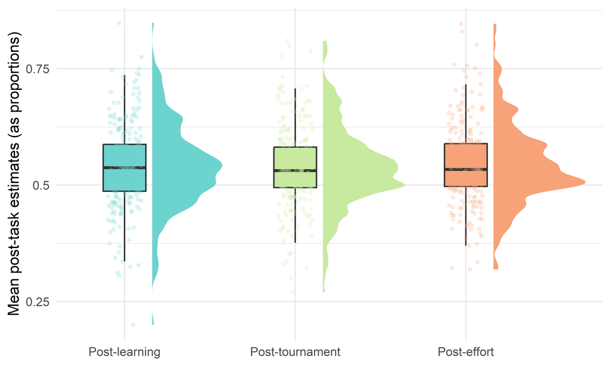

```r
# Prepare data for plotting
# Select three post-task estimate measures and convert to long format
summ_long <- reshape2::melt(summDf, id.vars = "prolificID",
                             measure.vars = c("postLearnMean_1",
                                             "postTournMean_1",
                                             "postEffortMean_1"))

# Create raincloud plot (combination of violin, boxplot, and points)
# This shows the full distribution at each timepoint
meanPostEstsRain <- ggplot(summ_long, aes(x = variable, y = value,
                                          fill = as.factor(variable))) +
  # Add half-violin plot showing distribution density
  ggdist::stat_halfeye(
    adjust = .5,           # Bandwidth adjustment for smoothing
    width = .6,            # Width of the violin
    .width = 0,            # Don't show interval
    justification = -.3,   # Position relative to box
    point_colour = NA) +   # No point in violin
  # Add boxplot showing median and quartiles
  geom_boxplot(
    width = .25,           # Width of boxplot
    outlier.shape = NA,    # Hide outliers (shown as points instead)
    aes(fill = as.factor(variable))) +
  # Add individual data points with jitter
  geom_point(
    inherit.aes = T,
    aes(color = as.factor(variable)),
    size = 1.5,
    alpha = .2,            # Transparency to show overlapping points
    position = position_jitter(seed = 1, width = .1)) +
  # Adjust plot area to accommodate violin
  coord_cartesian(xlim = c(1.2, 3.2), clip = "off") +
  scale_fill_brewer(palette = "Spectral") +
  labs(y = "Mean post-task estimates (as proportions)") +
  theme_minimal(base_size = 18) +
  theme(
    panel.background = element_rect(fill = "white", colour = "white"),
    legend.position = "none",
    axis.title.x = element_blank()) +
  # Custom x-axis labels
  scale_x_discrete(labels = c("postLearnMean_1" = "Post-learning",
                              "postTournMean_1" = "Post-tournament",
                              "postEffortMean_1" = "Post-effort")) +
  # Custom color scheme for each timepoint
  scale_fill_manual(values = c("postLearnMean_1" = "#6dd3ce",
                               "postTournMean_1" = "#c8e9a0",
                               "postEffortMean_1" = "#f7a278")) +
  scale_color_manual(values = c("postLearnMean_1" = "#6dd3ce",
                                "postTournMean_1" = "#c8e9a0",
                                "postEffortMean_1" = "#f7a278")) +
  # Set y-axis to show probabilities from 0 to 1
  scale_y_continuous(
    breaks = c(0, 0.25, 0.5, 0.75, 1),
    labels = c("0", "0.25", "0.5", "0.75", "1"))

print(meanPostEstsRain)
```

## Supplementary Figure 3 - Tournament Performance

Raincloud plots showing accuracy across different tournament trial types: overall, reward-only, loss-only, approach, and avoid trials.

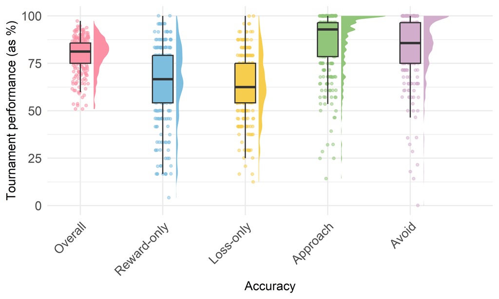

```r
# Prepare tournament performance data
# Five measures of tournament accuracy across different trial types
summ_long <- reshape2::melt(summDf, id.vars = "prolificID",
                             measure.vars = c("ovrperc",      # Overall accuracy
                                             "rewOvrPerc",    # Reward trials only
                                             "lossOvrPerc",   # Loss trials only
                                             "appPerc",       # Approach trials
                                             "avPerc"))       # Avoid trials

# Create raincloud plot
tournAccRain <- ggplot(summ_long, aes(x = variable, y = value,
                                      fill = as.factor(variable))) +
  # Half-violin showing distribution
  ggdist::stat_halfeye(
    adjust = .5,
    width = .6,
    .width = 0,
    justification = -.3,
    point_colour = NA) +
  # Individual data points
  geom_point(
    inherit.aes = T,
    aes(color = as.factor(variable)),
    size = 1.5,
    alpha = .5,
    position = position_jitter(seed = 1, width = .1)) +
  # Boxplot overlay
  geom_boxplot(
    width = .25,
    outlier.shape = NA,
    aes(fill = as.factor(variable))) +
  coord_cartesian(xlim = c(1.2, 5.4), clip = "off") +
  scale_fill_brewer(palette = "Spectral") +
  labs(
    y = "Tournament performance (as %)",
    x = "Accuracy") +
  theme_minimal(base_size = 18) +
  theme(
    panel.background = element_rect(fill = "white", colour = "white"),
    legend.position = "none",
    plot.title = element_text(hjust = 0.5, size = 16),
    axis.title.y = element_text(size = 18),
    axis.text.x = element_text(angle = 45, hjust = 1, size = 18),
    axis.text.y = element_text(size = 18)) +
  # Custom colors for each trial type
  scale_fill_manual(values = c("ovrperc" = "#fb8fa4",
                               "rewOvrPerc" = "#7dbedf",
                               "lossOvrPerc" = "#f7cd4d",
                               "appPerc" = "#91c579",
                               "avPerc" = "#d2aecc")) +
  scale_color_manual(values = c("ovrperc" = "#fb8fa4",
                                "rewOvrPerc" = "#7dbedf",
                                "lossOvrPerc" = "#f7cd4d",
                                "appPerc" = "#91c579",
                                "avPerc" = "#d2aecc")) +
  # Custom x-axis labels
  scale_x_discrete(labels = c("ovrperc" = "Overall",
                              "rewOvrPerc" = "Reward-only",
                              "lossOvrPerc" = "Loss-only",
                              "appPerc" = "Approach",
                              "avPerc" = "Avoid"))

print(tournAccRain)
```

## Supplementary Figure 4 - Correlation Matrix for Learning Measures

Correlation matrix showing relationships among five individualized learning measures. This helps validate that different learning measures capture similar underlying constructs.

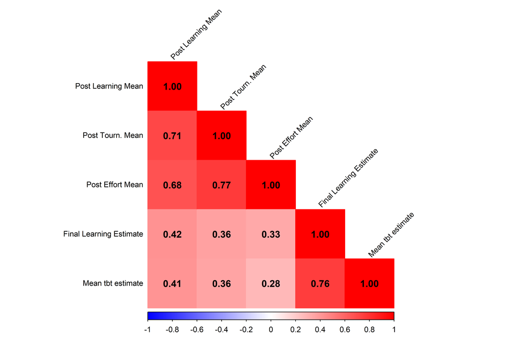

```r
# Compute the mean for each learning measure, grouped by participant
# This creates one value per participant per measure
rat_means <- tbtDf %>%
  group_by(prolificID) %>%
  summarise(
    plrMean = mean(postLearnRat, na.rm = TRUE),      # Post-learning rating
    ptrMean = mean(postTournRat, na.rm = TRUE),      # Post-tournament rating
    perMean = mean(postEffortRat, na.rm = TRUE),     # Post-effort rating
    fleMean = mean(as.numeric(finLearningEst), na.rm = TRUE),  # Final learning estimate
    mebsMean = mean(meanEstByStim, na.rm = TRUE)     # Mean trial-by-trial estimate
  )

# Convert to dataframe
rat_means <- as.data.frame(rat_means)

# Select only the learning measure columns (exclude prolificID)
corr_data <- rat_means[, c("plrMean", "ptrMean", "perMean", "fleMean", "mebsMean")]

# Compute Pearson correlation matrix
# use = "pairwise.complete.obs" handles missing data
cor_matrix <- cor(corr_data, use = "pairwise.complete.obs")

# Create readable labels for the correlation matrix
custom_labels <- c("Post Learning Mean",
                   "Post Tourn. Mean",
                   "Post Effort Mean",
                   "Final Learning Estimate",
                   "Mean tbt estimate")

# Apply custom labels to matrix
rownames(cor_matrix) <- custom_labels
colnames(cor_matrix) <- custom_labels

# Function to compute p-values for correlations
# Tests significance of each pairwise correlation
cor_pvalues <- function(mat) {
  n <- ncol(mat)
  p_mat <- matrix(NA, n, n)
  rownames(p_mat) <- colnames(mat)
  colnames(p_mat) <- colnames(mat)

  # Test each unique pair
  for (i in 1:(n-1)) {
    for (j in (i+1):n) {
      test <- cor.test(mat[, i], mat[, j],
                      use = "pairwise.complete.obs",
                      method = "pearson")
      p_mat[i, j] <- test$p.value
      p_mat[j, i] <- test$p.value  # Matrix is symmetric
    }
  }

  diag(p_mat) <- 0  # Set diagonal to 0
  return(p_mat)
}

# Compute p-values for significance testing
p_matrix <- cor_pvalues(corr_data)

# Generate the correlation matrix heatmap
# Shows lower triangle only (matrix is symmetric)
# Color gradient: blue (negative) → white (zero) → red (positive)
corrplot(cor_matrix,
         method = "color",                      # Use color squares
         type = "lower",                        # Show lower triangle only
         col = colorRampPalette(c("blue", "white", "red"))(200),  # Color gradient
         tl.col = "black",                      # Text label color
         tl.cex = 0.8,                         # Text label size
         tl.srt = 45,                          # Text label rotation
         addCoef.col = "black")                # Add correlation coefficients
```

## Supplementary Figure 5 - Questionnaire Distributions

Raincloud plots showing distributions of questionnaire scores: SHAPS (anhedonia), FAS (fatigue), and transdiagnostic factors (Anxious-Depression, Social Withdrawal, Compulsivity).

### SHAPS and FAS

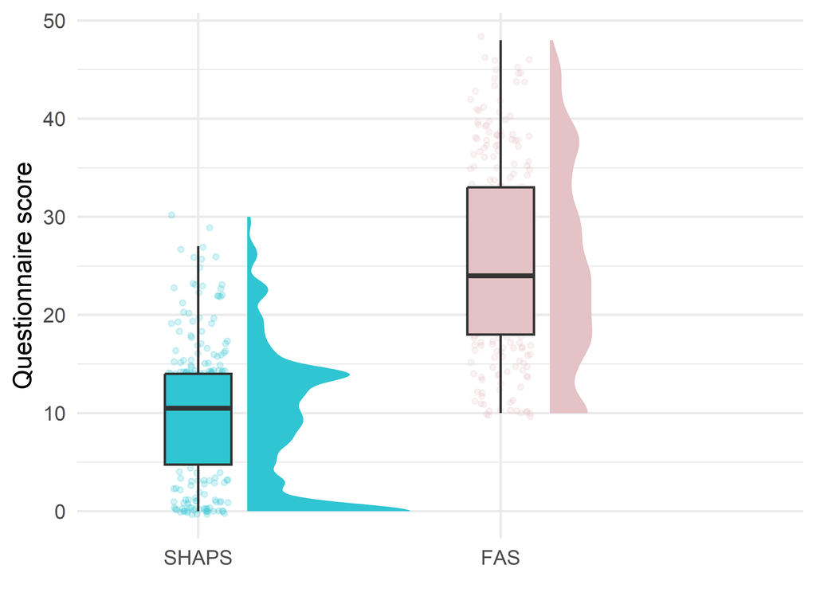

```r
# Prepare SHAPS and FAS data
summ_long <- reshape2::melt(summDf, id.vars = "prolificID",
                             measure.vars = c("SHAPS", "FAS"))

# Create raincloud plot for SHAPS and FAS
shapsFasRain <- ggplot(summ_long, aes(x = variable, y = value,
                                      fill = as.factor(variable))) +
  # Half-violin distribution
  ggdist::stat_halfeye(
    adjust = .5,
    width = .6,
    .width = 0,
    justification = -.3,
    point_colour = NA) +
  # Individual points with jitter
  geom_point(
    inherit.aes = T,
    aes(color = as.factor(variable)),
    size = 1.5,
    alpha = .2,
    position = position_jitter(seed = 1, width = .1)) +
  # Boxplot overlay
  geom_boxplot(
    width = .22,
    outlier.shape = NA,
    aes(fill = as.factor(variable))) +
  coord_cartesian(xlim = c(1.2, 2.4), clip = "off") +
  scale_fill_brewer(palette = "Spectral") +
  labs(
    x = "",
    y = "Questionnaire score") +
  theme_minimal(base_size = 18) +
  theme(
    panel.background = element_rect(fill = "white", colour = "white"),
    legend.position = "none") +
  scale_x_discrete(labels = c("SHAPS" = "SHAPS", "FAS" = "FAS")) +
  # Custom colors: cyan for SHAPS, pink for FAS
  scale_fill_manual(values = c("SHAPS" = "#30c5d2", "FAS" = "#E4C2C6")) +
  scale_color_manual(values = c("SHAPS" = "#30c5d2", "FAS" = "#E4C2C6"))

print(shapsFasRain)
```

### Transdiagnostic Factors

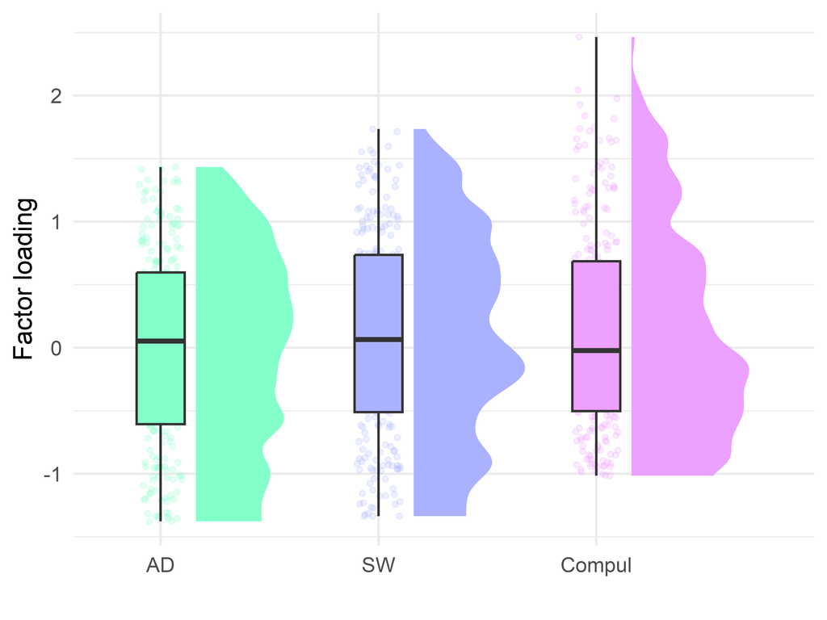

```r
# Prepare transdiagnostic factor data
# AD = Anxious-Depression
# SW = Social Withdrawal
# Compul = Compulsivity
summ_long <- reshape2::melt(summDf, id.vars = "prolificID",
                             measure.vars = c("AD", "SW", "Compul"))

# Create raincloud plot for transdiagnostic factors
transxRain <- ggplot(summ_long, aes(x = variable, y = value,
                                    fill = as.factor(variable))) +
  # Half-violin distribution
  ggdist::stat_halfeye(
    adjust = .5,
    width = .6,
    .width = 0,
    justification = -.3,
    point_colour = NA) +
  # Individual points with jitter
  geom_point(
    inherit.aes = T,
    aes(color = as.factor(variable)),
    size = 1.5,
    alpha = .2,
    position = position_jitter(seed = 1, width = .1)) +
  # Boxplot overlay
  geom_boxplot(
    width = .22,
    outlier.shape = NA,
    aes(fill = as.factor(variable))) +
  coord_cartesian(xlim = c(1.2, 3.4), clip = "off") +
  scale_fill_brewer(palette = "Spectral") +
  labs(
    x = "",
    y = "Factor loading") +
  theme_minimal(base_size = 18) +
  theme(
    panel.background = element_rect(fill = "white", colour = "white"),
    legend.position = "none") +
  scale_x_discrete(labels = c("AD" = "AD", "SW" = "SW", "Compul" = "Compul")) +
  # Custom colors for each factor
  scale_fill_manual(values = c("AD" = "#84ffc9",      # Green
                               "SW" = "#aab2ff",       # Blue
                               "Compul" = "#eca0ff")) + # Purple
  scale_color_manual(values = c("AD" = "#84ffc9",
                                "SW" = "#aab2ff",
                                "Compul" = "#eca0ff"))

print(transxRain)
```